# Data Investigation Notebook

## Discovering Patterns in the Russian Housing Market for Analysis and Prediction

### 3804ICT Assignment Part I | Data Investigation Notebook | Trimester 2, 2019

Joshua Russell (s5057545) | joshua.russell2@griffithuni.edu.au

Joshua Mitchell (s5055278) | joshua.mitchell4@griffithuni.edu.au

Hayden Flatley (s5088623) | hayden.flatley@griffithuni.edu.au

The sections of the data investigation are as follows:

**1. Data Exploration**

```
1.1. Number of Data Samples and Attributes
1.2. Types of Attributes
1.3. Feature Selection
1.4. Statistical Information
```

**2. Data Pre-Processing**

```
2.1. Data Quality
2.2. Data Cleaning
2.3. Data Transformation and Data Discretization
```

**3. Data Visualisation**

```
3.1. Graphing Statistical Information
3.2. Housing Market Share
3.3. District Property Sales
3.4. District Property Prices
3.5. Price by Property Distance to Utilities
3.6. House Material
3.7. Prices of Different Property States
3.8. Time Series Visualisation
3.9. Influence of Size on House Price
3.10. Insights into Housing Construction over Time
```

```python
# Imports
import math
import folium
import random
import warnings
import itertools
import statistics
import numpy as np
import pandas as pd
import xgboost as xgb
import seaborn as sns
import matplotlib as mpl
import matplotlib.pyplot as plt

from IPython.display import display
from geopy.geocoders import Nominatim
from sklearn import model_selection, preprocessing

warnings.filterwarnings("ignore")
%matplotlib inline
```

```python
# Load the Russian Housing Market datasets into pandas DataFrames
df_test = pd.read_csv("Data/test.csv")
df_train = pd.read_csv("Data/train.csv")
```

## 1. Data Exploration

### 1.1. Number of Data Samples and Attributes

The primary property dataset was provided online in two seperate files for training and testing. Below, we display the number of data samples and attributes in each of the datasets:

```python
# Testing set
print("Testing set\n- No. data samples: {}\n- No. of attributes: {}".format(df_test.shape[0], df_test.shape[1]))
```

```
Testing set
- No. data samples: 7662
- No. of attributes: 291
```

```python
# Training set
print("Training set\n- No. data samples: {}\n- No. of attributes: {}".format(df_train.shape[0], df_train.shape[1]))
```

```
Training set
- No. data samples: 30471
- No. of attributes: 292
```

The testing set has one less attribute than that of the training set. The following code checks the name of this attribute:

```python
list(set(df_train.columns).difference(set(df_test.columns)))[0]
```

```
'price_doc'
```

The data dictionary of the Russian Housing Market dataset describes this attribute as the sale price of the property, and moreover as the target variable for house price prediction. These two datasets will be useful for the methods of regression and forecasting. However, for other data mining methods we plan to investigate, such as frequent pattern mining, there is no need to split the data into training and testing sets. As a result, we will concatenate the datasets together for pre-processing.

```python
# Add a 'price_doc' column to the test DataFrame filled with NaN values
df_test_price_doc = df_test.assign(price_doc=pd.Series([np.nan for i in range(df_test.shape[0])]).values)
```

```python
# Concatenate test and train DataFrames
df = pd.concat([df_train, df_test_price_doc], sort=False, ignore_index=True)
```

```python
# Concatenate datasets (both training and testing data samples)
print("Complete dataset\n- No. data samples: {}\n- No. of attributes: {}".format(df.shape[0], df.shape[1]))
```

```
Complete dataset
- No. data samples: 38133
- No. of attributes: 292
```

### 1.2. Types of Attributes

Here we investigate the types of attributes within the dataset. For an initial look at these attributes we display each attribute with its corresponding datatype and an example value from the dataset

```python
# Attributes with corresponding Datatypes and Examples from the Russian Housing Market dataset
print("{:<40} {:<15} {}".format("Attribute", "Datatype", "Example Value"))
print("{:<40} {:<15} {}".format("---------", "--------", "-------------"))

example_values = []
for col in list(df.columns):
    values = [x for x in list(df[col].values) if str(x) != "nan"]
    example_values.append(values[0])

for col in np.c_[list(df.columns), list(df.dtypes), list(example_values)]:
    print("{:<40} {:<15} {}".format(col[0], str(col[1]), col[2]))
```

```
Attribute                                Datatype        Example Value
---------                                --------        -------------
id                                       int64           1
timestamp                                object          2011-08-20
full_sq                                  float64         43.0
life_sq                                  float64         27.0
floor                                    float64         4.0
max_floor                                float64         17.0
material                                 float64         1.0
build_year                               float64         1907.0
num_room                                 float64         2.0
kitch_sq                                 float64         11.0
state                                    float64         3.0
product_type                             object          Investment
sub_area                                 object          Bibirevo
area_m                                   float64         6407578.1
raion_popul                              int64           155572
green_zone_part                          float64         0.189727117
indust_part                              float64         6.99893e-05
children_preschool                       int64           9576
preschool_quota                          float64         5001.0
preschool_education_centers_raion        int64           5
children_school                          int64           10309
school_quota                             float64         11065.0
school_education_centers_raion           int64           5
school_education_centers_top_20_raion    int64           0
hospital_beds_raion                      float64         240.0
healthcare_centers_raion                 int64           1
university_top_20_raion                  int64           0
sport_objects_raion                      int64           7
additional_education_raion               int64           3
culture_objects_top_25                   object          no
culture_objects_top_25_raion             int64           0
shopping_centers_raion                   int64           16
office_raion                             int64           1
thermal_power_plant_raion                object          no
incineration_raion                       object          no
oil_chemistry_raion                      object          no
radiation_raion                          object          no
railroad_terminal_raion                  object          no
```

[output cut: 239 more lines]

```
cafe_avg_price_5000                      float64         947.14
cafe_count_5000_na_price                 int64           12
cafe_count_5000_price_500                int64           39
cafe_count_5000_price_1000               int64           48
cafe_count_5000_price_1500               int64           40
cafe_count_5000_price_2500               int64           9
cafe_count_5000_price_4000               int64           4
cafe_count_5000_price_high               int64           0
big_church_count_5000                    int64           13
church_count_5000                        int64           22
mosque_count_5000                        int64           1
leisure_count_5000                       int64           0
sport_count_5000                         int64           52
market_count_5000                        int64           4
price_doc                                float64         5850000.0
```

There are four distinct types of attributes, those being *nominal attributes*, *ordinal attributes*, *interval-scaled attributes* and *ratio-scaled attributes*. Furthermore, there are also discrete and continuous classifications for distinguishing types of attributes. Since there are a total of 292 attributes in the primary dataset we will not describe the specific attribute type for each attribute. Instead, we will provide examples of attributes from the dataset that fulfill the criteria of the different attribute types.

**Nominal Attributes**

Nominal attributes are those which are qualitative and do not have any inherent order or ranking. An example of this type of attribute within the dataset is the `sub_area` attribute. This attribute represents the name of the district that the data sample (property) belongs to. It takes on values such as "Juzhnoe Butovo" and "Perovo".

**Ordinal Attributes**

Ordinal attributes are again qualitative. However, the values that these attributes take on have a meaningful order. In the primary housing market dataset there are no attributes that are ordinal.

**Interval-Scaled Attributes**

Interval-scaled attributes are ordered, and are those which, as the name implies, are measured on a particular equal-sized interval scale. The distinguishing factor between interval-scaled attributes and ratio-scaled attributes is that interval-scaled attributes do not have a true zero point (i.e. they can be positive, zero, or negative). After observing the name and meaning of each of the attributes in the primary dataset, we did not find any attributes that appeared interval-scaled. We further check this observation below:

```python
# Check for negative values in DataFrame
for col_name in list(df.columns):
    col = df[col_name]

    if col.dtype == "float64" or col.dtype == "int64":
        neg_values = []

        for val in col:
            if not math.isnan(val) and val < 0:
                neg_values.append(val)

        if neg_values:
            print("Column: {}".format(col_name))
            print("Negative values: {}".format(len(neg_values)))
```

**Ratio-Scaled Attributes**

Ratio-scaled attributes, like those which are interval-scaled, are ordered measurements which have a particular scale. However, what differentiates ratio-scaled attributes is that they have a true zero point (i.e. they can be positive or zero). An example of a ratio-scaled attribute within the housing market dataset is `full_sq`. This attribute represents the total area of the property in square meters. Since area has an inherent zero-point, as you cannot have a house with negative area, this is a clear example of a ratio-scaled attribute.

**Discrete Attributes**

Discrete attributes are attributes which take on a finite or countably infinite set of possible values. The attribute `product_type` is an example of a discrete attribute within the primary dataset. This attribute states whether the property was bought as an investment property, or for owner-occupancy. Since there are two possible values this attribute can take on (i.e. "OwnerOccupier" or "Investment"), it has a finite set of values and is therefore a discrete attribute.

**Continuous Attributes**

Continuous attributes, in contrast to discrete attributes, take on real valued numbers over a continuous range. An example of this type of attribute in the Russian housing market dataset is `metro_min_walk`, which provides the time it would take to walk to the metro on foot from the property (in minutes). This attribute has floating-point values over a continuous range and can therefore be classified as a continuous attribute.

### 1.3. Feature Selection

The primary Russian housing market dataset contains a significant number of attributes, 292 in total. Consequently, for this investigation we will perform feature selection to select a few attributes which seem interesting and/or significant for predicting property sale price to study in data exploration and visualisation. Firstly, we will perform manual feature selection by examining the features and using domain knowledge to determine which attributes should not be investigated. We will then use metrics and data analysis techniques to determine which attributes seem most promising to examine.

#### Manual Selection

The following attributes were selected for data exploration and visualisation based upon our domain knowledge of what attributes would be significant in predicting house price and what attributes would be interesting to study.

`price_doc` - this attribute represents the sale price of the property. This attribute will be interesting to explore as it allows us to find trends in the price and determine what other attributes are correlated to house price. Furthermore, the sale price will be the target variable for our regression and forecasting methods.

`full_sq` - this attribute represents the total area of the property in square meters (including loggias, balconies and other non-residential living areas). We believe that the total area of the property would be a strong indicator for gauging the price of the property. As larger homes are generally more expensive than smaller ones.

`sub_area` - this attribute represents the name of the district that the property is within. Characteristics of the district, such as its reputation, its population, or whether it has a large central business district will all affect the price of the property and other property/neighbourhood attribute values. Because of this, we thought that it would be interesting to explore.

`num_room` - this attribute represents the number of living rooms in the property. Since the number of rooms is generally thought to be an indicator of house price (i.e. the more rooms the greater the price) we thought that investigating this attribute would be worthwhile.

`build_year` - this attribute represents the year that the property was built. Since newer appartments and homes are generally more expensive, we assume that this attribute will be useful for predicting house price. Furthermore, it may also allude to interesting relationships between house age and the district, or house age and the demographic information of the neighbourhood.

`state` - this attribute represents the condition that the property is in at the time of purchase. Properties in bad condition are typically purchased at a lower price since the home buyer will need to invest additional money into the property in order to fix it up. This attribute could therefore provide insight into predicting property price, as well as the general characteristics of people and/or properties within a particular district.

#### Metric-Based Selection - Correlation Analysis

```python
# Get the first n number of attributes that most highly correlate with price_doc
high_corr_list = df.corr()["price_doc"].abs().sort_values()[-30:].keys()

# Remove redundant items
items_to_remove = ["trc_sqm_3000", "cafe_count_5000_na_price", "trc_count_3000", "sport_count_3000"]
high_corr_list = list(set(high_corr_list).difference(set(items_to_remove)))

# Calculate correlation matrix between list of attributes defined by high_corr_list
corr = df[high_corr_list].corr()
```

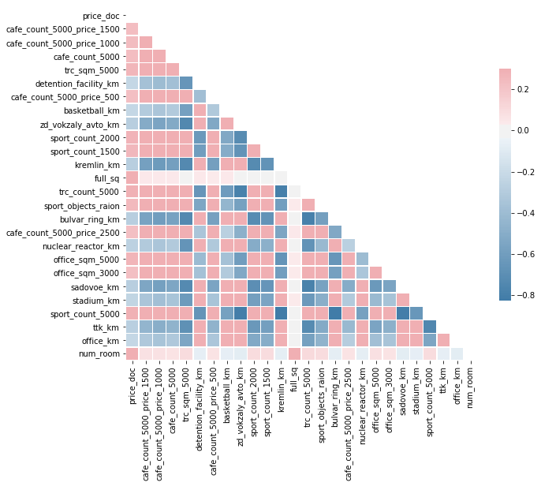

```python
# Mask out the squares on the right side of the diagonal
mask = np.zeros_like(corr, dtype=np.bool)
mask[np.triu_indices_from(mask)] = True

# Set up the matplotlib figure
f, ax = plt.subplots(figsize=(10, 9))

# Create a custom color map for the heatmap
cmap = sns.diverging_palette(240, 10, as_cmap=True)

# Draw the heatmap with the mask and correct aspect ratio
sns.heatmap(corr, mask=mask, cmap=cmap, vmax=.3, center=0,
            square=True, linewidths=.5, cbar_kws={"shrink": .6})
plt.show()
```

Below lists the 26 of the attributes with the highest absolute correlation to the house price. Due to the categorical data of this set not being encoded and ordinal this algorithm has only correlated numerical attributes. Attributes such as the number of rooms and size of the properties are shown to have a high positive correlation with price. While this is quite obvious, the algorithm also described some interesting relationships through the negative correlations. As the distance to the city center decreases, and the distance to features of the city centre such as garden rings, train stations and boulevards decrease, the price of houses increase.

```python
corr['price_doc'].sort_values(ascending=False)
```

```
price_doc                     1.000000
num_room                      0.476337
full_sq                       0.341840
sport_count_5000              0.294864
trc_count_5000                0.289371
sport_count_2000              0.278056
office_sqm_5000               0.269977
trc_sqm_5000                  0.268072
sport_count_1500              0.258376
sport_objects_raion           0.252794
cafe_count_5000_price_1000    0.240464
cafe_count_5000_price_1500    0.232612
cafe_count_5000               0.231546
cafe_count_5000_price_500     0.226952
office_sqm_3000               0.226780
cafe_count_5000_price_2500    0.225566
detention_facility_km        -0.223061
office_km                    -0.223429
basketball_km                -0.223462
stadium_km                   -0.236924
nuclear_reactor_km           -0.257946
ttk_km                       -0.272620
bulvar_ring_km               -0.279158
kremlin_km                   -0.279249
sadovoe_km                   -0.283622
zd_vokzaly_avto_km           -0.284069
Name: price_doc, dtype: float64
```

#### Metric-Based Selection - Extreme Gradient Boosting

Another algorithm which determines stronger relationships between attributes and a target result such as the house price is Extreme Gradient Boosting. This algorithm constructs a gradient boosted tree, which is essentially an optimised decision tree, to assign attributes scores on how influential they are in classifying the output.

The algorithm requires categorical data to be encoded so the code below first converts all data of type object to an encoded label.

Parameters that the tree model for the XBG library require include the max depth of the tree, learning rate(eta) and error function.

```python
for f in df_train.columns:
    if df_train[f].dtype=='object':
        lbl = preprocessing.LabelEncoder()
        lbl.fit(list(df_train[f].values))
        df_train[f] = lbl.transform(list(df_train[f].values))

y_train = df_train.price_doc.values
x_train = df_train.drop(["id", "timestamp", "price_doc"], axis=1)


param = {'max_depth': 10, 'eta': 1, 'objective': 'reg:squarederror'}


dtrain = xgb.DMatrix(x_train, y_train, feature_names=x_train.columns.values)
model = xgb.train(dict(param, silent=0), dtrain, num_boost_round=10)

importance = model.get_score()
importance = dict(sorted(importance.items(), key=lambda importance: importance[1], reverse=True))
importance = dict(itertools.islice(importance.items(), 20))
importance
```

```
{'full_sq': 482,
 'life_sq': 185,
 'floor': 174,
 'max_floor': 104,
 'build_year': 89,
 'kitch_sq': 56,
 'state': 47,
 'num_room': 40,
 'public_transport_station_km': 39,
 'industrial_km': 33,
 'metro_min_avto': 31,
 'sub_area': 31,
 'market_shop_km': 29,
 'material': 28,
 'park_km': 28,
 'green_zone_km': 27,
 'fitness_km': 26,
 'school_km': 25,
 'kindergarten_km': 25,
 'metro_min_walk': 24}
```

Listed above are the 20 attributes scored highest on influencing the `price_doc` feature. The list is quite rational as it includes all our manually selected features we predicted to be highly influential. The additionally listed features such as the square area of the kitchen and the distance to various utilities are intuitive to be very influential. The remaining features to be used in data exploration will be selected from the above list. Features that will not be included are `metro_min_walk` as its similarity to `metro_min_avto` would be redundent in relation to the house prices. `kindergarten_km` will also be excluded for it's similarity to `school_km`.

The below plot describes the attribute importances.

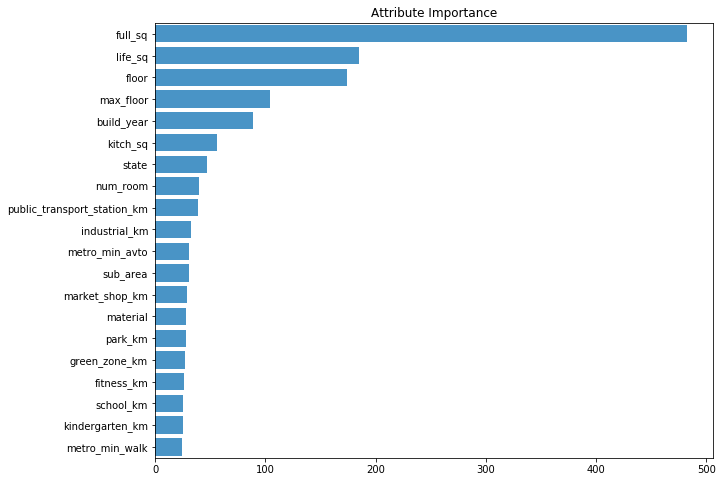

```python
importanceDf = pd.Series(importance)

fig, ax = plt.subplots(figsize=(10,8))

b = sns.barplot(y=importanceDf.keys(), x=importanceDf,orient='h', ax=ax, color='#3498db')
b.set_yticklabels(importanceDf.keys())
b.set_title('Attribute Importance')
plt.show()
```

#### Selecting Attributes

Here we create a DataFrame with the selected attributes for data exploration and visualisation.

```python
df_exp = df[["timestamp", "price_doc", "full_sq", "sub_area", "num_room", "build_year", "state",
             "public_transport_station_km", "industrial_km", "metro_min_avto",
             "market_shop_km", "material", "park_km", "green_zone_km", "school_km"]]
```

### 1.4. Statistical Information

Within this section we examine the statistical information of the selected attributes. This exploration provides a statistical overview of the attributes which will be useful for proposing pre-processing questions and in gaining a better understanding of the data. There are two categories of measures that provide us with a rather comprehensive picture of the data. These are measures of central tendency and measures of spread. We explore each category below.

#### Measures of Central Tendency

Measures of central tendency provide us with information about the "typical values" of a certain data distribution. With this information we can gather an understanding of what the values of a particular attribute are likely to be. Here we will examine four measures of central tendency: mean, median, midrange and mode. The mean tells us what the average value of the attribute is, the median tells us the midpoint of the values of the attribute (i.e. the point splitting the data into lower and higher halves), the midrange tells us the centre value of the range, and the mode tells us what value occurs the most.

Mean

```python
# Here we display the arithmetic mean of the selected attributes which contain numerical data
print("{:<30} {}".format("Numerical Attribute", "Mean"))
print("{:<30} {}".format("-------------------", "----"))
for num_col in list(df_exp.describe().columns):
    print("{:<30} {:.3f}".format(num_col, df_exp[num_col].describe()["mean"]))
```

```
Numerical Attribute            Mean
-------------------            ----
price_doc                      7123035.278
full_sq                        54.111
num_room                       1.901
build_year                     2716.785
state                          2.072
public_transport_station_km    0.424
industrial_km                  0.767
metro_min_avto                 4.903
market_shop_km                 3.938
material                       1.834
park_km                        3.065
green_zone_km                  0.301
school_km                      1.347
```

After examing the means of the numerical attributes, we found that the mean for `build_year` appears to be quite odd. Since, at time of writing, it is 2019 and therefore having a mean `build_year` of 2716 does not make any sense. We assume that there are some noisy `build_year` values that are skewing this mean above its expected value.

Median

```python
# Here we display the median of the selected attributes which contain numerical data
print("{:<30} {}".format("Numerical Attribute", "Median"))
print("{:<30} {}".format("-------------------", "------"))
for num_col in list(df_exp.describe().columns):
    print("{:<30} {:.3f}".format(num_col, df_exp[num_col].describe()["50%"]))
```

```
Numerical Attribute            Median
-------------------            ------
price_doc                      6274411.000
full_sq                        50.000
num_room                       2.000
build_year                     1980.000
state                          2.000
public_transport_station_km    0.163
industrial_km                  0.572
metro_min_avto                 2.770
market_shop_km                 2.888
material                       1.000
park_km                        1.787
green_zone_km                  0.217
school_km                      0.480
```

Midrange

```python
# Here we display the midrange of the selected attributes which contain numerical data
print("{:<30} {}".format("Numerical Attribute", "Midrange"))
print("{:<30} {}".format("-------------------", "--------"))
for num_col in list(df_exp.describe().columns):
    smallest_val = df_exp[num_col].describe()["min"]
    largest_val = df_exp[num_col].describe()["max"]
    print("{:<30} {:.3f}".format(num_col, (smallest_val + largest_val) / 2))
```

```
Numerical Attribute            Midrange
-------------------            --------
price_doc                      55605556.000
full_sq                        2663.000
num_room                       9.500
build_year                     10026004.500
state                          17.000
public_transport_station_km    8.708
industrial_km                  7.024
metro_min_avto                 32.551
market_shop_km                 20.554
material                       3.500
park_km                        23.678
green_zone_km                  1.018
school_km                      23.697
```

The midrange provided us with quite a lot of insight into the potential noisiness of the data. Firstly, we found that the midrange of the `state` attribute was significantly greater than its corresponding median and mean. This suggests that there is an extreme data point skewing the midrange. We also observe this pattern in the midrange, mean and median of the `build_year` attribute. This gives us some intuition behind why the mean of `build_year` was skewed greater than a realistic value, as there must be a noisy entry that is far larger than the other data points. Lastly, we also see that the `price_doc` attribute's midrange increased by a large amount. Since this attribute represents the sale price of the property, there may have been a special property, or several special properties, sold for a large sum of money. Moreover, it may also just be noise.

Mode

```python
# Here we display the mode of the selected attributes
print("{:<30} {}".format("Attribute", "Mode"))
print("{:<30} {}".format("---------", "----"))
for col in list(df_exp.columns):
    mode = list(df_exp[col].value_counts().keys())[0]
    print("{:<30} {}".format(col, mode))
```

```
Attribute                      Mode
---------                      ----
timestamp                      2014-12-16
price_doc                      2000000.0
full_sq                        38.0
sub_area                       Poselenie Sosenskoe
num_room                       2.0
build_year                     2014.0
state                          2.0
public_transport_station_km    0.035986494
industrial_km                  0.0
metro_min_avto                 4.721044964
market_shop_km                 5.43973407
material                       1.0
park_km                        4.616176397
green_zone_km                  0.0
school_km                      0.214196513
```

The attribute modes support the findings that were discussed above under *Midrange*.

#### Measures of Spread

Measures of spread provide us with information about how spread out our data distribution is. Using this information, we can gather an understanding of how similar or dissimilar the values of a particular attribute are. Here we will investigate the dispersion of the data by examining the variance and standard deviation of the selected attributes, as well as their five number summaries. The variance and standard deviation tell us how much the values of an attribute differ from the mean of the attribute. The five number summary provides us with an overview of the spread of the data distribution, specifically examining the minimum value, maximum value, and quartiles (thus including the median) of the attribute.

Variance and Standard Deviation

```python
# Here we display the variance and standard deviation of the selected attributes which contain numerical data
print("{:<30} {:<20} {}".format("Numerical Attribute", "Variance", "Standard Deviation"))
print("{:<30} {:<20} {}".format("-------------------", "--------", "------------------"))
for num_col in list(df_exp.describe().columns):
    stddev = df_exp[num_col].describe()["std"]
    var = stddev**2
    print("{:<30} {:<20.3f} {:.3f}".format(num_col, var, stddev))
```

```
Numerical Attribute            Variance             Standard Deviation
-------------------            --------             ------------------
price_doc                      22849464323693.328   4780111.330
full_sq                        1237.011             35.171
num_room                       0.718                0.848
build_year                     17122270234.215      130852.093
state                          0.748                0.865
public_transport_station_km    1.830                1.353
industrial_km                  0.552                0.743
metro_min_avto                 41.912               6.474
market_shop_km                 12.090               3.477
material                       2.223                1.491
park_km                        15.331               3.915
green_zone_km                  0.086                0.294
school_km                      9.980                3.159
```

In agreeance with our findings in *Measures of Central Tendency*, the `build_year` attribute appears to have data values that are significantly greater than the other data values. Based upon the context of the attribute, we have classified these extreme values as noise. The variance and standard deviation further support this point. In contrast, the other selected numerical attributes appear to have relatively standard values for variance and standard deviation.

Five Number Summary

```python
# Here we display the five number summary of the selected attributes which contain numerical data
print("{:<30} {:<15} {:<15} {:<15} {:<15} {}".format("Numerical Attribute", "Min", "Q1", "Median", "Q3", "Max"))
print("{:<30} {:<15} {:<15} {:<15} {:<15} {}".format("-------------------", "---", "--", "------", "--", "---"))
for num_col in list(df_exp.describe().columns):
    five_min = df_exp[num_col].describe()["min"]
    five_q1 = df_exp[num_col].describe()["25%"]
    five_median = df_exp[num_col].describe()["50%"]
    five_q3 = df_exp[num_col].describe()["75%"]
    five_max = df_exp[num_col].describe()["max"]

    print("{:<30} {:<15.3f} {:<15.3f} {:<15.3f} {:<15.3f} {:.3f}".format(num_col, five_min, five_q1,
                                                                         five_median, five_q3, five_max))
```

```
Numerical Attribute            Min             Q1              Median          Q3              Max
-------------------            ---             --              ------          --              ---
price_doc                      100000.000      4740002.000     6274411.000     8300000.000     111111112.000
full_sq                        0.000           38.900          50.000          63.000          5326.000
num_room                       0.000           1.000           2.000           2.000           19.000
build_year                     0.000           1966.000        1980.000        2006.000        20052009.000
state                          1.000           1.000           2.000           3.000           33.000
public_transport_station_km    0.003           0.103           0.163           0.280           17.413
industrial_km                  0.000           0.287           0.572           1.040           14.048
metro_min_avto                 0.000           1.719           2.770           4.789           65.101
market_shop_km                 0.004           1.541           2.888           5.440           41.104
material                       1.000           1.000           1.000           2.000           6.000
park_km                        0.004           0.965           1.787           3.304           47.352
green_zone_km                  0.000           0.103           0.217           0.420           2.037
school_km                      0.000           0.273           0.480           0.899           47.395
```

The five number summaries of the attributes displayed above provide the most insightful characteristics about the spread of the data and what data points may be skewing the statistical measures investigated above. Firstly, we see that the maximum sale price of a property within the database was 111,111,112 Russian rubles. This is significantly greater than the third quartile of `price_doc` at 8,300,000 Russian rubles. The midrange deviation we observed from the mean and median can be explained by this observation. The second illuminating factor is the maximum and minimum values of the `build_year` attribute. Both of these values appear to be noise. The minimum value is considered to be noise as it is very unlikely that a building being sold in Russia is 2019~ years old. Furthermore, the maximum value is considered to be noise as it appears that there was a data entry error, in which 2005 and 2009 were entered side-by-side for the same property. This explains the unrealistic mean value and midrange value observed above in *Measures of Central Tendency*. We observed an interesting max value for the attribute `state`. The mean, median, mode, quartiles and standard deviation all allude to the fact that this attribute's data distribution is centered around 2 and is likely within the range of 1 - 3 or 1 - 4. However, the maximum value observed for this attribute is 33. We can therefore hypothesise that this value is noise. Lastly, we presume that the minimum value for `full_sq` is also a noisy value. Since this attribute represents the "total area in square meters" of the property. A property with no area being purchased on the market seems improbable, which is why we consider this value to be noise.

#### Conclusion

The statistical exploration of the selected attributes conducted above showed that there are unexpected, potentially noisy data points within the dataset. Before we visualise these measures, it would be sensible to pre-process the attributes to remove any noise that may skew the distributions and present false representations of the data. Consequently, the next section investigates data pre-processing.

To conclude our data exploration, we display the time range of the Russian housing market dataset.

```python
time_series = pd.to_datetime(df.timestamp)
print('Time Range:\n{} - {}'.format(time_series.min(), time_series.max()))
```

```
Time Range:
2011-08-20 00:00:00 - 2016-05-30 00:00:00
```

## 2. Data Pre-Processing

### 2.1. Data Quality

Raw data generally isn't initially suitable for data mining. Poor data quality can dramatically reduce accuracy and lead to incorrect conclusions. Data quality may be affected by the introduction of noise from incorrect data entry or erroneous data from sensors. Outliers skew the distribution of attributes and missing values make it more difficult do get an accuracte representation of the model behind the data. The easiest method for dealing with outliers and missing values is to simply delete/drop them from the dataframe. This provides convenience at the expense of statistical significance due to smaller sample sizes. Therefore, where values are predictable/computatble, we apply methods which replace these values.

#### Data Mechanism

In our data pre-processing we make the assumption that the data is 'Missing at Random', such that missing values are independent of other attributes.

### 2.2. Data Cleaning

The process of data cleaning involves finding data with incorrect formatting, data with missing values, outliers, data that is erroneous, inconsistent, intentionally incorrect, irrelevant and malicious, and either correcting or removing those samples. The types of data mentioned here are collectively known as "dirty" data. We will briefly describe the types of dirty data below.

- **Outliers:** data that is deviated from or inconsistent with other data in the dataset, also referred to as noise or anomolies
- **Formatting:** data containing the same information with inconsistent formatting
- **Erroneous data:** data that is erroneous with respect to other samples or in regard to the context of the information
- **Irrelevant data:** data that does not affect the results of statistical or analitical methods
- **Inconsistent data:** data that can be represented in two or more ways
- **Malicious data:** data designed to cause damage or an undesired effect
- **Intentionally incorrect data:** data that is intentionally entered to be incorrect
- **Incomplete (missing) data:** data samples with missing variable information

For the process of data cleaning, all removals and corrections of data will be made to the complete dataframe `df` (the dataframe containing all attributes and all data samples (from both the test and train set)). These changes can then simply be applied to the selected attributes for data visualisation.

#### Incomplete (Missing) Data

Here we examine the missing data within the entire Russian housing market dataset.

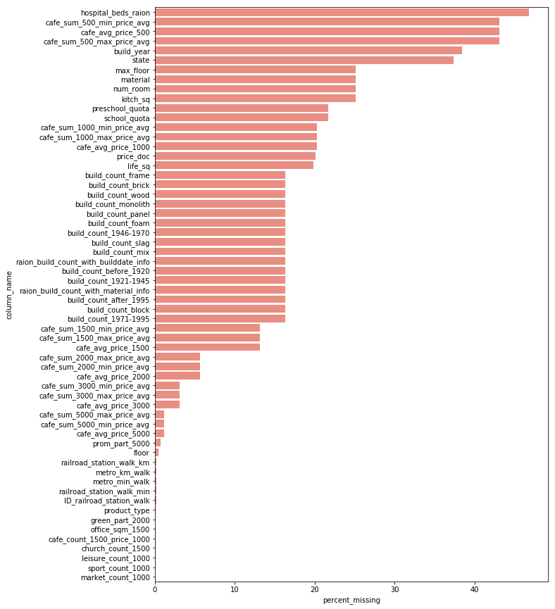

```python
# Calculate the percentage of missing values for each attribute
percent_missing = df.isnull().sum() * 100 / len(df)

# Create a DataFrame of the percentages and sort the attributes in decending order of percentage missing values
missing_value_df = pd.DataFrame({'column_name': df.columns,
                                 'percent_missing': percent_missing})
missing_value_df.sort_values('percent_missing', inplace=True, ascending=False)

# Display a barplot of the top 60 missing value percentage attributes
f, ax = plt.subplots(figsize=(10, 15))
sns.barplot(missing_value_df.percent_missing[0:60], missing_value_df.column_name[0:60], color="salmon", ax=ax)
plt.show()
```

```python
print("Percent missing 'price_doc' [train set]: {}%".format(df_train["price_doc"].isnull().sum() * 100 / len(df["price_doc"])))
```

```
Percent missing 'price_doc' [train set]: 0.0%
```

The floor attribute can be seen to be not missing many values from the above graph. The statement below demonstrates that wherever the floor value is null, the max_floor attribute is also null. This would make it likely that these houses are a part of buildings with 1 floor. This data will be cleaned by filling these values with 1.

```python
# Check properties that have `floor` and `max_floor` as null
(df.floor.isnull() == (df.floor.isnull()) & (df.max_floor.isnull())).value_counts()
```

```
True    38133
dtype: int64
```

```python
# Replace these null values with 1
df.loc[df.floor.isnull(), 'floor'] = 1
df.loc[df.floor.isnull(), 'max_floor'] = 1
```

Here we check for cases where the house floor number is greater than the number of floors in the building. In this case, we just set the max floor to be the floor number, as we know the max will be at the least that value.

```python
# Print the number of properties with `floor` greater than `max_floor`
len(df.loc[(df['floor'] > df['max_floor'])])
```

```
2136
```

```python
# Set these properties to have a `max_floor` equal to that of `floor`
df.loc[(df['floor'] > df['max_floor']), 'max_floor'] = df.loc[(df['floor'] > df['max_floor']), 'floor']
```

#### Intentionally Incorrect Data

Above within *1.4. Statistical Information* we saw that the minimum value for `build_year` was 0. Intentionally incorrect data is data that is entered typically to hide particular information, such as January 1st for a birthday. This approach may have also been used to hide the property age by entering an uninformative value for `build_year`.

```python
df[(df.build_year < 1000)]["build_year"].value_counts()
```

```
0.0      899
1.0      555
215.0      2
3.0        2
71.0       1
2.0        1
20.0       1
Name: build_year, dtype: int64
```

The value counts of the attribute `build_year` above show that 0 was entered 899 times and 1 was entered 555 times. Both these value counts seem too frequent to be considered accidental or random noise. As a result, we believe that these values of 0 and 1 for `build_year` are intentionally incorrect data within the Russian housing market dataset. Such values will be dealt with within the next section.

#### Noisy Data

In *1.4. Statistical Information*, we found that there were attributes with measures of central tendency and spread that suggested that some of the values of the attributes were noisy. These attributes were `price_doc`, `build_year`, `state` and `full_sq`. Here we examine these attributes further and correct other noisy data points that we found while examining the data.

State

```python
df["state"].value_counts()
```

```
2.0     8506
3.0     7703
1.0     7121
4.0      549
33.0       1
Name: state, dtype: int64
```

By examining the value counts for the attribute `state`, we see that the data value of 33 was indeed noise (as it only occurs once and is significantly different to the other values of 1 to 4). Since this attribute represents the condition of the property, with 1 being poor condition and 4 being the highest condition, we could deal with this noisy data point by simply setting it to the attribute median, 2. However, since the same data sample's `build_year` is also a noisy value (see below) we will just drop the data sample.

```python
print("The 'build_year' of data sample with 'state' equal to 33: {}".format(list(df[(df.state == 33)]["build_year"])[0]))
```

```
The 'build_year' of data sample with 'state' equal to 33: 20052009.0
```

```python
df = df.drop(df[(df.state > 4)].index)
```

Build Year

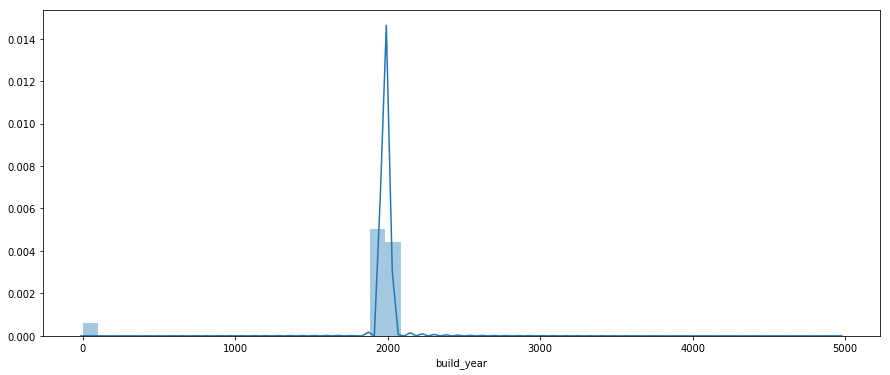

```python
f, ax = plt.subplots(figsize=(15, 6))
sns.distplot(df["build_year"].dropna(), ax=ax)
plt.show()
```

```python
print("No. of properties built after the year 2019: {}".format(len(df[(df.build_year > 2019)])))
print("No. of properties built before the year 1000: {}".format(len(df[(df.build_year < 1000)])))
```

```
No. of properties built after the year 2019: 1
No. of properties built before the year 1000: 1461
```

```python
df[(df.build_year < 1000)]["build_year"].value_counts()
```

```
0.0      899
1.0      555
215.0      2
3.0        2
71.0       1
2.0        1
20.0       1
Name: build_year, dtype: int64
```

The histogram of `build_year` above shows an extreme value around 5000, and a small group of properties with `build_year` as 0. The cell below the histogram tells us that there is only one value greater than 2019, and 1461 values below 1000. Diving into even more detail, in the cell directly above we see the counts of the values of the attribute `build_year` below 1000. Since these values are all very likely to be noise, we will simply drop them from the DataFrame.

House Price (price_doc)

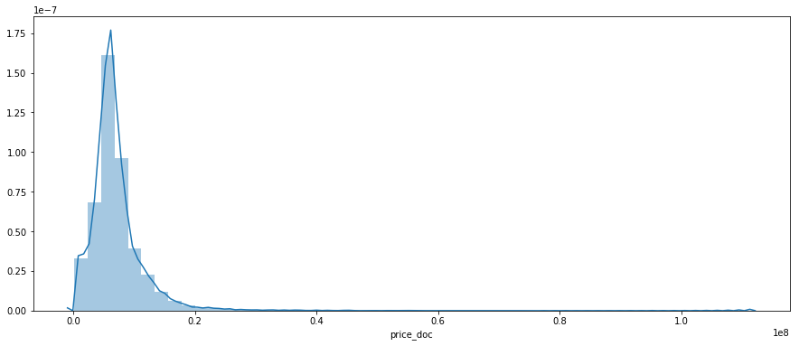

```python
f, ax = plt.subplots(figsize=(15, 6))
sns.distplot(df["price_doc"].dropna(), ax=ax)
plt.show()
```

```python
print("No. of properties sold above the price of 70,000,000 rubles: {}".format(len(df[(df.price_doc > 70000000)])))
```

```
No. of properties sold above the price of 70,000,000 rubles: 9
```

```python
df[(df.price_doc > 70000000)]["price_doc"].value_counts()
```

```
91066096.0     1
77000000.0     1
95122496.0     1
111111112.0    1
71033632.0     1
78802248.0     1
71249624.0     1
80777440.0     1
71200000.0     1
Name: price_doc, dtype: int64
```

The above analysis of the `price_doc` attribute shows that the majority of the houses were sold between 0 and 20,000,000 rubles. However, the extreme value we observed in *1.4. Statistical Information* appears to simply be the most expensive property that was bought. There is a steady increase in property value up until the maximum amount. Therefore, we believe it was just an expensive property, rather than noise. As a result, we will keep these values within the DataFrame as they are interesting data points to observe, and we believe they are indeed real.

Total Area (full_sq)

```python
print("No. of properties with full area equal to 0: {}".format(len(df[(df.full_sq == 0)])))
```

```
No. of properties with full area equal to 0: 3
```

As stated within *1.4. Statistical Information*, having a property with `full_sq` equal to 0 does not make sense. The cell above shows that there are 3 properties with 0 total area in square meters. Rather than immediately removing these data samples from the DataFrame, we will leave them until a later investigation. Since if for these data samples there exists a `life_sq` value of the property, then we can simply set the `full_sq` value to equal that of the `life_sq` value. As `full_sq` would, by definition, be larger than or equal to `life_sq`.

The dataset describes the `full_sq` attribute to be the full square area in metres including balconies, loggias and other non-residential areas. The `life_sq` attribute describes the living area of the property excluding these feautres. We therefore need to clean the data such that the `life_sq` is never greater than the `full_sq`. In these cases we should set the `full_sq` to just be the `life_sq` as it is likely the data may have been entered in reverse.

```python
# Check the number of cases where life_sq > full_sq
condition = (df.life_sq > df.full_sq)
len(df[condition])
```

```
49
```

```python
# Set full_sq to be equal to life_sq in these cases
df.loc[condition, 'full_sq'] = df[condition]["life_sq"]
```

Perform Data Removal for the Analysis Above

```python
# Build Year
df = df.drop(df[(df.build_year > 2019) | (df.build_year < 1000)].index)
```

#### Outlier Detection

Here we apply a basic statistical method to check for outliers in the selected numerical attributes. This method simply checks if a value is plus or minus three standard deviations away from the mean of the attribute, and if so, classifies it as an outlier.

```python
# Here we display the median of the selected attributes which contain numerical data
print("{:<30} {}".format("Numerical Attribute", "No. Outliers"))
print("{:<30} {}".format("-------------------", "------------"))
for num_col in list(df_exp.describe().columns):
    stddev = df[num_col].std()
    mean = df[num_col].mean()
    lower_bound = mean - 3 * stddev
    upper_bound = mean + 3 * stddev
    num_outliers = len(df[ (df[num_col] < lower_bound) | (df[num_col] > upper_bound) ][num_col])
    print("{:<30} {:.3f}".format(num_col, num_outliers))
```

```
Numerical Attribute            No. Outliers
-------------------            ------------
price_doc                      450.000
full_sq                        41.000
num_room                       77.000
build_year                     75.000
state                          0.000
public_transport_station_km    445.000
industrial_km                  206.000
metro_min_avto                 1448.000
market_shop_km                 464.000
material                       0.000
park_km                        1540.000
green_zone_km                  724.000
school_km                      654.000
```

Since there is not a significant number of outliers present (based upon this simple statistical method), and the context of the attributes makes it understandable for there to be some relatively large differences in values, we will not remove any data samples.

### 2.3. Data Transformation and Data Discretization

We cannot use numerical data for association rule mining since the total number of possible itemsets would increase significantly if we were to use them. One way to work around this is to perform attribute/feature construction and construct categorical attributes from the numerical ones. This is somewhat like binning, where we will define a fixed set of ranges for the categorical classes and simply assign a categorical class to the data sample based upon which range its numerical value falls into. In this initial data investigation, we will use this data transformation method on distance attributes in the dataset (e.g. `park_km`). However, in the final investigation when we are implementing the algorithms, we will most probably apply this technique to many numerical attributes in the Russian housing market dataset.

Distance to Park (park_km)

```python
df["park_km"].describe()
```

```
count    36670.000000
mean         2.966196
std          3.788395
min          0.003737
25%          0.963479
50%          1.773759
75%          3.151855
max         47.351538
Name: park_km, dtype: float64
```

Here we will define three distance classes for the `park_km` attribute, `NEAR`, `MODERATE` and `FAR`. The ranges that these classes represent were chosen by ourselves, using domain knowledge about what would be considered nearby, a moderate distance away, or far away. These ranges are `[0.0, 1.0)`, `[1.0, 2.0)` and `[2.0, 50.0)`, respectively (where 50.0 is set as the upper bound of the `FAR` range since the maximum value for this attribute is 47.35). Below we construct a new attribute from these classes.

```python
# Add a 'park_km_class' column to the DataFrame filled with None values
df = df.assign(park_km_class=pd.Series([None for i in range(df.shape[0])]).values)
```

```python
# Define a function for mapping from 'park_km' to 'park_km_class'
def park_km_class_mapping_func(x):
    if 0.0 <= x["park_km"] < 1.0:
        return "NEAR"
    elif 1.0 <= x["park_km"] < 2.0:
        return "MODERATE"
    elif 2.0 <= x["park_km"] < 50.0:
        return "FAR"
    else:
        print("Unexpected value: {}".format(x["park_km"]))
        return None
```

```python
# Apply the mapping function to set the class values for 'park_km_class'
df["park_km_class"] = df.apply(park_km_class_mapping_func, axis=1)
```

```python
df["park_km_class"].value_counts()
```

```
FAR         15911
MODERATE    10919
NEAR         9840
Name: park_km_class, dtype: int64
```

Above we see that the `park_km_class` attribute was successfully constructed from the `park_km` attribute. This can now be used to more efficiently represent the distance to the nearest park for a particular property in tasks such as association rule mining.

Total Property Area (full_sq)

```python
df["full_sq"].describe()
```

```
count    36670.000000
mean        54.340876
std         53.095317
min          1.000000
25%         38.700000
50%         49.000000
75%         63.000000
max       7478.000000
Name: full_sq, dtype: float64
```

```python
# Add a 'full_sq_class' column to the DataFrame filled with None values
df = df.assign(full_sq_class=pd.Series([None for i in range(df.shape[0])]).values)
```

```python
# Define a function for mapping from 'full_sq' to 'full_sq_class'
def full_sq_class_mapping_func(x):
    if 0.0 <= x["full_sq"] < 45.0:
        return "SMALL"
    elif 45.0 <= x["full_sq"] < 65.0:
        return "MEDIUM"
    elif 65.0 <= x["full_sq"] < 5500.0:
        return "LARGE"
    else:
        print("Unexpected value: {}".format(x["full_sq"]))
        return None
```

```python
# Apply the mapping function to set the class values for 'full_sq_class'
df["full_sq_class"] = df.apply(full_sq_class_mapping_func, axis=1)
```

```
Unexpected value: 7478.0
```

```python
df["full_sq_class"].value_counts()
```

```
SMALL     15553
MEDIUM    13029
LARGE      8087
Name: full_sq_class, dtype: int64
```

## 3. Data Visualisation

### 3.1. Graphing Statistical Information

Within this section we visualise the selected numerical attributes from *1.4. Statistical Information* after they have been pre-processed. We firstly examine these attributes by plotting box plots of their five-number summaries. These box plots give us an overview of the spread of the data and also display extreme points which may suggest the need for further noise/outlier investigations. Due to the fact that two different distributions of data can be represented by the same box plot, we also display histograms of the attributes. Histograms divide the values of the attributes into bins and show a graph that is representative of the distribution of the data. This will improve our understanding of the shape of the distributions in the Russian housing market dataset.

```python
# Collect numerical attributes to plot
num_attributes = []
num_attributes_titles = []
for num_col in list(df_exp.describe().columns):
    if num_col != "price_doc":
        num_attributes.append(df[num_col].dropna())
        num_attributes_titles.append(num_col)
```

#### Box plots

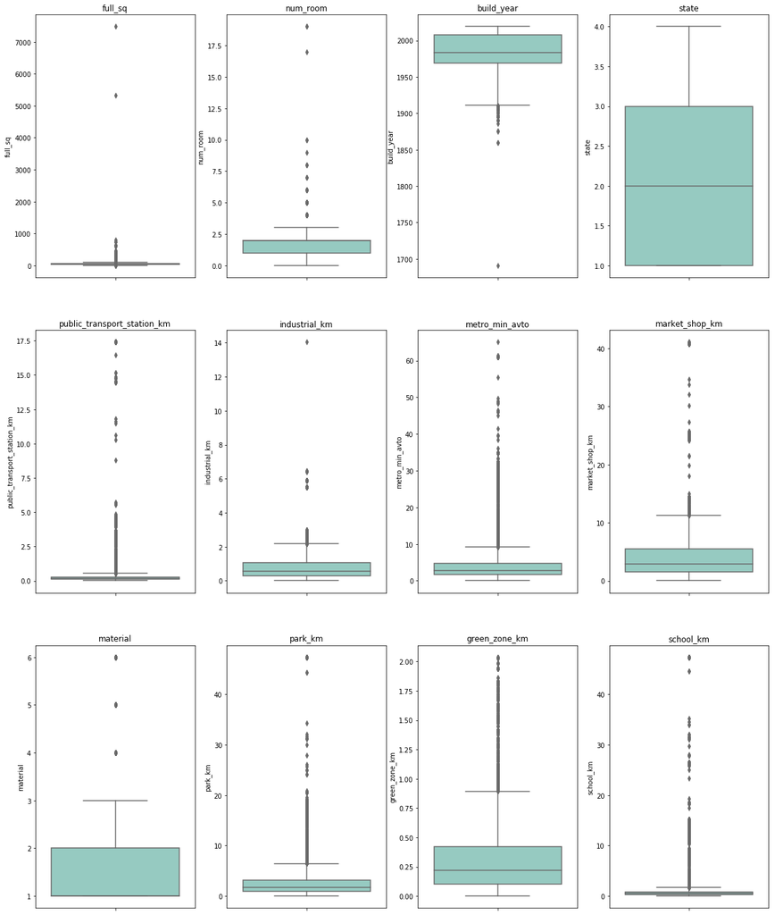

```python
# Plot box plots of the numerical attributes
fig, ax = plt.subplots(figsize=(20, 25))
for i in range(0, 12):
    plt.subplot(3, 4, i + 1)
    sns.boxplot(num_attributes[i], labels=[num_attributes_titles[i]], orient="v", palette="Set3")
    plt.title(num_attributes_titles[i])
plt.show()
```

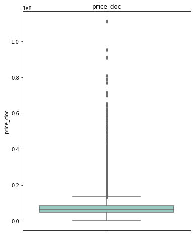

```python
# Plot box plot of the 'price_doc' attribute
fig, ax = plt.subplots(figsize=(6, 8))
sns.boxplot(df["price_doc"].dropna(), labels=["price_doc"], orient="v", palette="Set3")
plt.title("price_doc")
plt.show()
```

The most insightful information that we received by examining the selected numerical attributes with box plots is that there are quite a significant number of data points beyond the maximum extreme point threshold (i.e. greater than `Q3 + 1.5 * IQR`, where Q3 is the third quartile and IQR is the interquartile range). This suggests lots of different characteristic about the properties within the dataset. For example, the properties that are far from a school (`school_km`), or those that are far from the metro (`metro_min_avto`), may be in more rural areas/districts. Moreover, there appears to be a countable number of properties with `num_room` greater than 3. This suggests that there may be a few large properties that have recently been sold on the market (perhaps mansions or castles). However, the fact that the majority of the data seems to fall within a relatively small range suggests that there are commonalities between properties beind sold. This may be a useful property to investigate for sale price prediction, and may aid our investigation of patterns with clustering and association rule mining.

#### Histograms

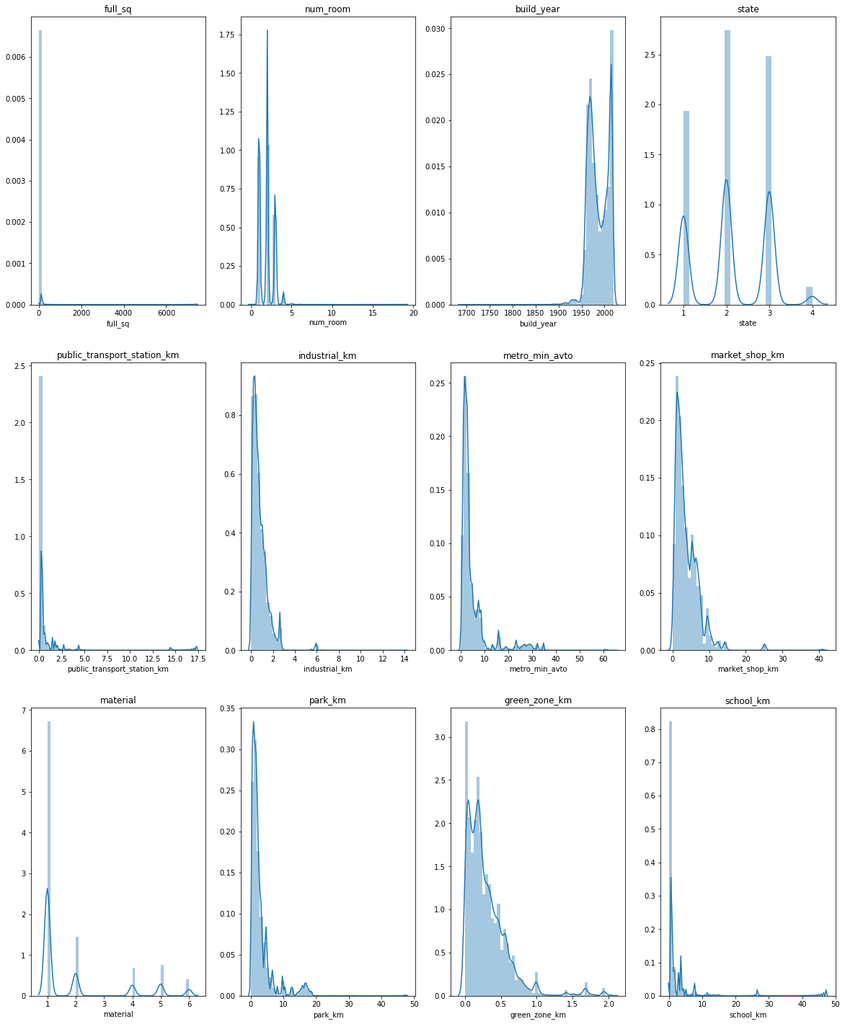

```python
# Plot histograms of the numerical attributes
fig, ax = plt.subplots(figsize=(20, 25))
for i in range(0, 12):
    plt.subplot(3, 4, i + 1)
    sns.distplot(num_attributes[i])
    plt.title(num_attributes_titles[i])
plt.show()
```

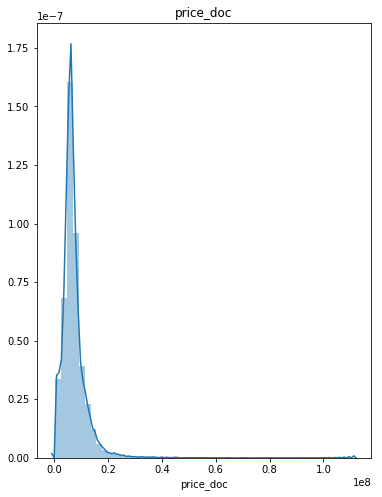

```python
# Plot histogram of the 'price_doc' attribute
fig, ax = plt.subplots(figsize=(6, 8))
sns.distplot(df["price_doc"].dropna())
plt.title("price_doc")
plt.show()
```

The histograms above show that a significant number of the selected numerical attributes have right-skewed distributions. The `build_year` attribute is the only distribution that appears left-skewed. However, this makes sense when considering the context of the attribute. It is expected that as `build_year` decreases, so would the sold property count. Since there are fewer properties that still remain from that time, and many new apartments and properties are being built.

### 3.2. Housing Market Share

Here we examine the housing market share of different attribute properties. Since we are interested in visualising what percentage of the dataset a particular value represents, we will use a pie chart for visualisation. We decided to explore three attributes from the dataset, `product_type`, `ecology`, and `nuclear_reactor_raion`. These are discussed in more detail below.

#### Property Product Type (product_type)

The `product_type` attribute specifies whether the property was purchased for owner occupancy, or as an investment property. We found that two thirds of the purchased properties were purchased as investment properties, while the remaining one third were purchased for the home buyer. This is a facinating observation. Later within this data investigation we find that the majority of the districts are within Moscow. This tells us that the real estate market within the past few years within Moscow has involved lots of investors buying properties in the area. This supports the notion that the vast majority of properties within this dataset are apartments, rather than houses. Since apartments are good for investment properties. Furthermore, if investors are purchasing properties, it generally means that the housing market is increasing in cost. This information may prove useful in our forecasting and regression investigations.

```python
# Reset matplotlib display settings
mpl.rcParams.update(mpl.rcParamsDefault)

# Find the sold property counts for each product type
values = df['product_type'].value_counts().keys().tolist()
counts = df['product_type'].value_counts().tolist()

# Normailze counts into the range of 0-100%
s = sum(counts)
market_shares = [c/s for c in counts]

# Capitalise the titles of each product type for visualisation
product_types = [w.title() for w in values]
```

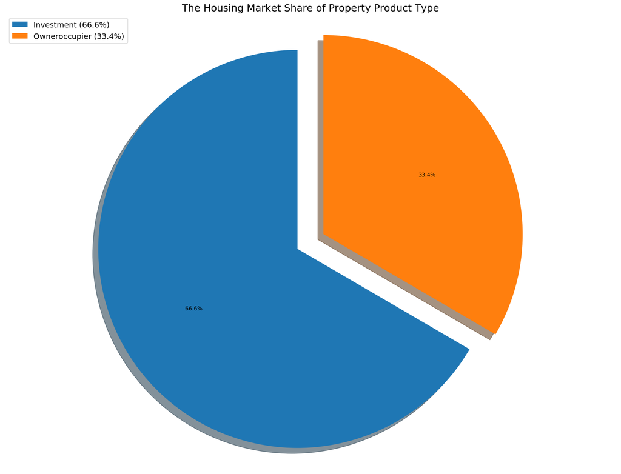

```python
# Plot the property product types in order of their market share (counter-clockwise)
fig, ax = plt.subplots(figsize=(20, 15))
explode = [0.15 if i == 0 else 0.0 for i in range(len(product_types))]
ax.pie(market_shares, explode=explode, autopct='%1.1f%%', shadow=True, startangle=90)
ax.axis('equal')

plt.legend(["{} ({:.1f}%)".format(product_types[i], market_shares[i] * 100) for i in range(len(product_types))],
           loc="best", fontsize=14)
plt.title("The Housing Market Share of Property Product Type", fontsize=18)
plt.show()
```

#### Property Ecological Zone Classification (ecology)

The attribute `ecology` represents the classification of the ecological zone where the house is located. This attribute takes on five possible values: `no data`, `poor`, `satisfactory`, `good` and `excellent`. Surprisingly, the most common ecological zone classification was `poor`, followed by `good`, `excellent` and then `satisfactory` (excluding `no data`). Since the majority of the districts are within Moscow, we assume that the `poor` ecological zones would be in built-up areas right in the middle of the city, with lots of buildings and few plants. In contrast, we assume that the `good` and `excellent` ecological zones are on the outskirts of Moscow, or even further out in more rural areas. Since each ecological zone classification has a significant number of properties, it will be interesting to observe relationships and correlations with this attribute in clustering and association rule mining.

```python
# Reset matplotlib display settings
mpl.rcParams.update(mpl.rcParamsDefault)

# Find the sold property counts of each ecology classification
values = df['ecology'].value_counts().keys().tolist()
counts = df['ecology'].value_counts().tolist()

# Normailze counts into the range of 0-100%
s = sum(counts)
market_shares = [c/s for c in counts]

# Capitalise the titles of each ecology classification for visualisation
ecology_classes = [w.title() for w in values]
```

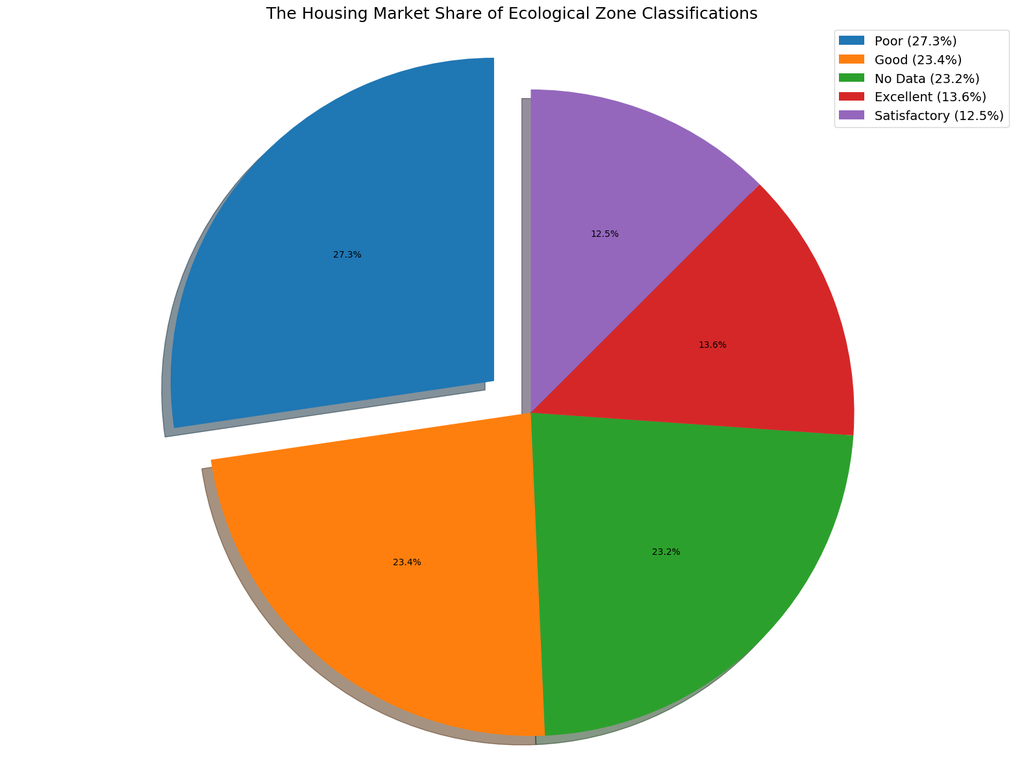

```python
# Plot the property ecology classifications in order of their market share (counter-clockwise)
fig, ax = plt.subplots(figsize=(20, 15))
explode = [0.15 if i == 0 else 0.0 for i in range(len(ecology_classes))]
ax.pie(market_shares, explode=explode, autopct='%1.1f%%', shadow=True, startangle=90)
ax.axis('equal')

plt.legend(["{} ({:.1f}%)".format(ecology_classes[i], market_shares[i] * 100) for i in range(len(ecology_classes))],
           loc="best", fontsize=14)
plt.title("The Housing Market Share of Ecological Zone Classifications", fontsize=18)
plt.show()
```

#### Property Districts with Nuclear Reactors (nuclear_reactor_raion)

The attribute `nuclear_reactor_raion` specifies the presence of existing nuclear reactors within the district that the property is located in. We thought that this attribute would be interesting to explore since we assumed that the value of a property would be significantly less if it were within an area in which a nuclear reactor was present. Moreover, we wanted to see what percentage of properties belonged to a district in which a nuclear reactor was located. We found (through observing the pie chart below) that only 3% of the properties in the dataset were located in a district where a nuclear reactor was present. We hypothesise that this means that the nuclear reactors around Moscow are located within a particular few districts. It will be interesting to observe whether this district with a nuclear reactor has any strong relationships with other attributes in the database when we do clustering and association rule mining. Furthermore, it may be a strong attribute for the task of classifying properties into different districts (at least for a few of the districts within the database).

```python
# Reset matplotlib display settings
mpl.rcParams.update(mpl.rcParamsDefault)

# Find the sold property counts of districts with and without an existing nuclear reactor
values = df['nuclear_reactor_raion'].value_counts().keys().tolist()
counts = df['nuclear_reactor_raion'].value_counts().tolist()

# Normailze counts into the range of 0-100%
s = sum(counts)
market_shares = [c/s for c in counts]

# Change the titles of nuclear reactor existence classes for visualisation
existence_class = ["Reactor Present" if w.lower() == "yes" else "Reactor Not Present" for w in values]
```

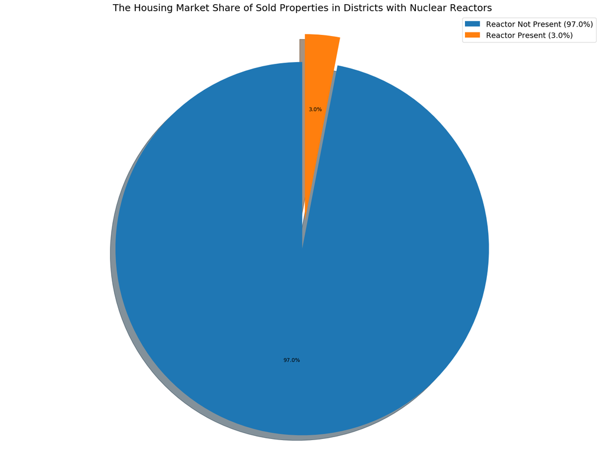

```python
# Plot the property nuclear reactor existence class in order of their market share (counter-clockwise)
fig, ax = plt.subplots(figsize=(20, 15))
explode = [0.15 if i == 0 else 0.0 for i in range(len(existence_class))]
ax.pie(market_shares, explode=explode, autopct='%1.1f%%', shadow=True, startangle=90)
ax.axis('equal')

plt.legend(["{} ({:.1f}%)".format(existence_class[i], market_shares[i] * 100) for i in range(len(existence_class))],
           loc="best", fontsize=14)
plt.title("The Housing Market Share of Sold Properties in Districts with Nuclear Reactors", fontsize=18)
plt.show()
```

#### Properties with Varying Floor Quantities

Looking at the distribution of the `floor` attribute we see a step pattern where the apartment floor peaks at 4 floors and drops by about 0.02 percent every 3 - 4 floors until tailing off after 17 floors. This coincides with the most common max floor of 17 which is followed by a very sharp decline and preceeded by a sporadic incline.

From this distribution of floors it's apparent that most properties in the dataset are urban apartments.

We can see that buildings with 1, 5, 9, 12, 14, 16, 17, 22, and 25 floors are far more common than those inbetween.

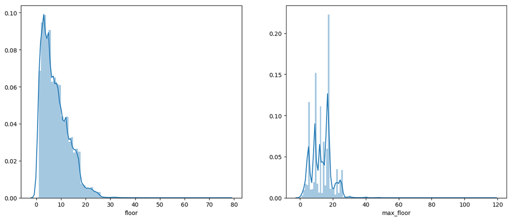

```python
# Plot the distribution of floor and max floor to find patterns within building floors
f, ax = plt.subplots(1, 2, figsize=(15, 6))
sns.distplot(df.loc[df.floor.notnull()]["floor"], bins=77, ax=ax[0])
sns.distplot(df.loc[df.max_floor.notnull()]["max_floor"], bins=117, ax=ax[1])
plt.show()
```

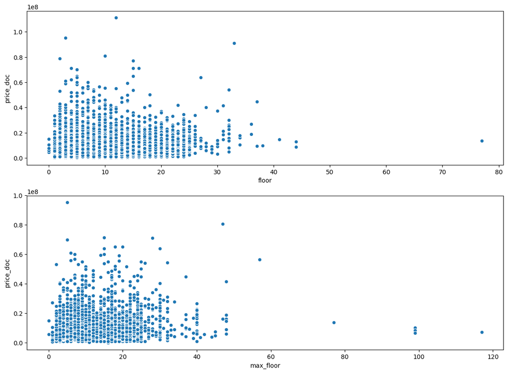

```python
# Plot price against floor and max floor to see how it affects price
f, ax = plt.subplots(2, 1, figsize=(14, 10))
sns.scatterplot(x=df.floor, y=df.price_doc, ax=ax[0])
sns.scatterplot(x=df.max_floor, y=df.price_doc, ax=ax[1])
plt.show()
```

### 3.3. District Property Sales

Here we investigate the number of property sales in each district. In order to gain an intuition behind where these districts are located, we decided to visualise this information spatially on a map. Below, is a world map zoomed into Moscow. The first interesting observation we made was that the majority of the districts within the dataset are within and around Moscow, Russia. The map can be moved around to see more rural districts to the north and south-east. An important point to make is that any district that could not be found by the geolocator package is not displayed, and would instead be output by the cell directly below. Out of the districts that were found, Nekrasovka has the most property sales (located to the east of Moscow). We observed that the outskirt districts around the city were more frequently bought in, in comparison to the districts within the centre of Moscow. Moreover, the number of properties purchased in more rural areas was much less than the majority within Moscow. This spatial information will be interesting to investigate further when we begin to implement data mining methods.

```python
# Find the house purchase counts of each district
values = df['sub_area'].value_counts().keys().tolist()
counts = df['sub_area'].value_counts().tolist()

# Normailze counts into the range of 0-100%
s = sum(counts)
market_shares = [c/s for c in counts]

# Capitalise the titles of each district for visualisation
districts = [w.title() for w in values]

# Find the corresponding latitudes and longitudes of the districts
located_districts = []
location_latitudes = []
location_longitudes = []
located_location_sales_count = []
located_location_market_shares = []

geolocator = Nominatim(user_agent='joshua_russell', timeout=10)

for i, location in enumerate(districts):
    loc = geolocator.geocode(location + ", Moscow, Russia")

    # Only record data for districts whose latitude and longitude could be found
    if loc is not None:
        located_districts.append(location)
        location_latitudes.append(loc.latitude)
        location_longitudes.append(loc.longitude)
        located_location_sales_count.append(counts[i])
        located_location_market_shares.append(market_shares[i])
    else:
        print("District '{}' could not be located.".format(location))

# Create a DataFrame to plot the circles on the map
data = pd.DataFrame({
    "lat": location_latitudes,
    "lon": location_longitudes,
    "district": located_districts,
    "market_share": located_location_market_shares,
    "sales_count": located_location_sales_count
})
```

```
District 'Poselenie Sosenskoe' could not be located.
District 'Poselenie Vnukovskoe' could not be located.
District 'Poselenie Moskovskij' could not be located.
District 'Tverskoe' could not be located.
District 'Poselenie Voskresenskoe' could not be located.
District 'Juzhnoe Butovo' could not be located.
District 'Nagatinskij Zaton' could not be located.
District 'Krjukovo' could not be located.
District 'Poselenie Shherbinka' could not be located.
District 'Poselenie Desjonovskoe' could not be located.
District 'Poselenie Filimonkovskoe' could not be located.
District 'Gol'Janovo' could not be located.
District 'Chertanovo Juzhnoe' could not be located.
District 'Horoshevo-Mnevniki' could not be located.
District 'Tekstil'Shhiki' could not be located.
District 'Birjulevo Vostochnoe' could not be located.
District 'Ochakovo-Matveevskoe' could not be located.
District 'Kosino-Uhtomskoe' could not be located.
District 'Danilovskoe' could not be located.
District 'Akademicheskoe' could not be located.
District 'Orehovo-Borisovo Juzhnoe' could not be located.
District 'Orehovo-Borisovo Severnoe' could not be located.
District 'Veshnjaki' could not be located.
District 'Mozhajskoe' could not be located.
District 'Kuncevo' could not be located.
District 'Presnenskoe' could not be located.
District 'Sokolinaja Gora' could not be located.
District 'Rjazanskij' could not be located.
District 'Novogireevo' could not be located.
District 'Filevskij Park' could not be located.
District 'Obruchevskoe' could not be located.
District 'Losinoostrovskoe' could not be located.
District 'Timirjazevskoe' could not be located.
District 'Juzhnoe Tushino' could not be located.
District 'Severnoe Izmajlovo' could not be located.
District 'Teplyj Stan' could not be located.
District 'Beskudnikovskoe' could not be located.
District 'Shhukino' could not be located.
District 'Cheremushki' could not be located.
District 'Donskoe' could not be located.
```

[output cut: 28 more lines]

```
District 'Zamoskvorech'E' could not be located.
District 'Kapotnja' could not be located.
District 'Krasnosel'Skoe' could not be located.
District 'Poselenie Rjazanovskoe' could not be located.
District 'Poselenie Rogovskoe' could not be located.
District 'Poselenie Krasnopahorskoe' could not be located.
District 'Poselenie Kokoshkino' could not be located.
District 'Poselenie Mosrentgen' could not be located.
District 'Poselenie Voronovskoe' could not be located.
District 'Poselenie Marushkinskoe' could not be located.
District 'Poselenie Shhapovskoe' could not be located.
District 'Molzhaninovskoe' could not be located.
District 'Poselenie Kievskij' could not be located.
District 'Poselenie Mihajlovo-Jarcevskoe' could not be located.
District 'Poselenie Klenovskoe' could not be located.
```

```python
# Create an empty map centered at Russia
m = folium.Map(location=[55.7558, 37.6173], zoom_start=10)

# Add circles at each location scaled to the market share of the particular location
for i in range(0, len(data)):
   folium.Circle(
      location=[float(data.iloc[i]["lat"]), float(data.iloc[i]["lon"])],
      popup=str("<strong>{}</strong> ({} Property Sales)".format(data.iloc[i]["district"], data.iloc[i]["sales_count"])),
      radius=float(data.iloc[i]["market_share"]*100000),
      color='crimson',
      fill=True,
      fill_color='crimson'
   ).add_to(m)

# Display the map
display(m)
```

[interactive chart not shown]

```python
# Save the map to a HTML file
m.save("Russian-House-Market-Share-Map.html")
```

### 3.4. District Property Prices

Here we investigate the prices of properties within each district. By sorting the districts by average sale price, we find that the district with the most expensive average sale price is Hamovniki, and the district with the least expensive average sale price is Poselenie Klenovskoe. Interestingly, the most expensive property in the dataset is not within Hamovniki. Moreover, the districts with the most expensive average property price do not have a wider distribution that is evenly spread out. Instead, like the other districts, they have a group of property prices which appear to be around the average price, and then some expensive properties that seems relatively spaced out. The district Arbat is unique in this regard, where it appears to only have a few properties in total. From this information, we gather that using sale price for classifying properties into districts may be quite useful.

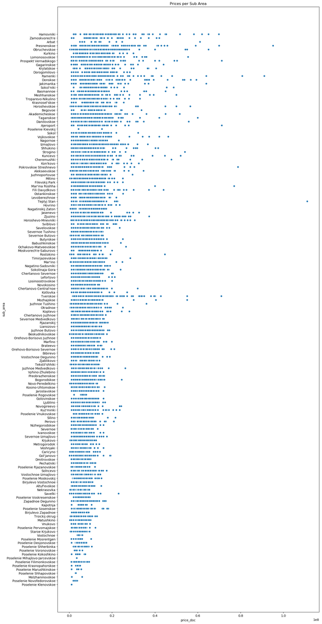

```python
# Order the most expensive sub areas by grouping them and getting their average price
sorted_sub_area = df.groupby("sub_area")["price_doc"].mean().sort_values().reset_index()["sub_area"]

# Place each sub area into dictionary along with their rank
sorterIndex = dict(zip(sorted_sub_area,range(len(sorted_sub_area))))

# Create a new column in df
df['sub_area_rank'] = df['sub_area'].map(sorterIndex)

# Sort the sub areas by rank
df1 = df.sort_values(by='sub_area_rank')

# Plot the sub areas with their house prices in order according to their average house price
f, ax = plt.subplots(figsize=(15, 35))
p = sns.scatterplot(y=df1.sub_area, x=df1.price_doc, ax=ax)
p.set_title("Prices per Sub Area")
plt.show()
```

### 3.5. Price by Property Distance to Utilities

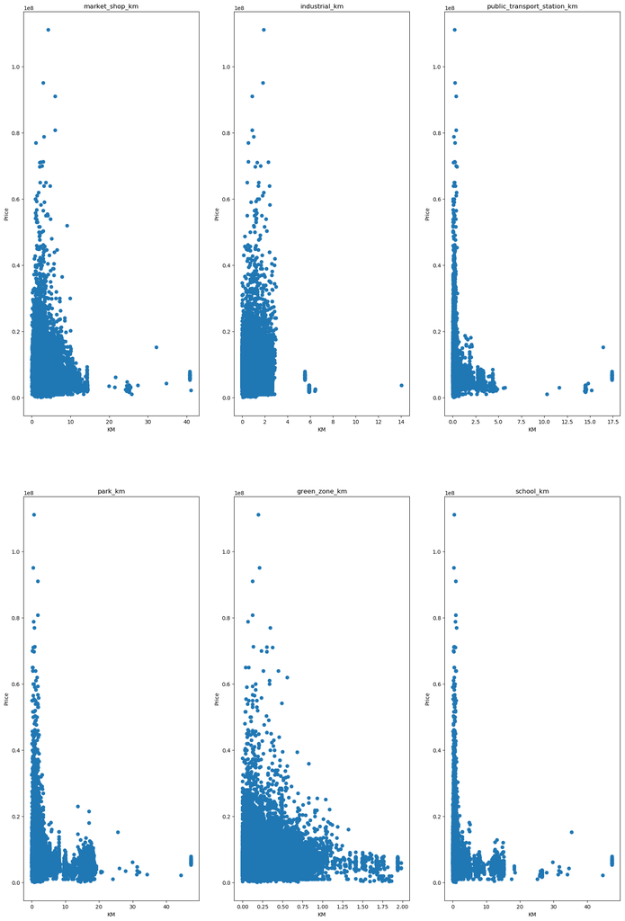

```python
# Get list of attributes which provide distances to local public services etc.
distList = ['market_shop_km', 'industrial_km', 'public_transport_station_km', 'park_km', 'green_zone_km', 'school_km']

# Plot each attribute alongside prices to see how they affect it.
fig, axs = plt.subplots(2,3,figsize=(20,30))
ax_iter = iter(axs.flat)
for d in distList:
    ax = next(ax_iter)
    ax.set_xlabel("KM")
    ax.set_ylabel("Price")
    ax.set_title(d)
    ax.scatter(x=df[d], y=(df["price_doc"]))
```

### 3.6. House Material

Here we investigate the different materials that properties in the dataset are built out of. Our first investigation looks at the overall material distribution in the dataset. We see that panel is the most common material that purchased properties are made of by a significant margin. Wood on the other hand appears to be the main material of a minimal number of properties, while the rest of the other materials seem to have relatively the same counts. We then examine the distribution of materials per district (i.e. `sub_area`) and interestingly find that different districts rather distinctively use different materials. Within the districts examined, we see that panel, brick and wood in some cases represent the material of the majority of properties sold within that district. This attribute may therefore be useful in the task of district classification. Lastly, we explore the relationship between sale price and material. The most expensive sold properties are shown to be made out of brick. All materials appear to take part in the average property price, with the least spread distribution belonging to wood. There appears to be some limits in price of particular materials, which suggests to us that this attribute may also be useful for regression analysis in predicting sale price.

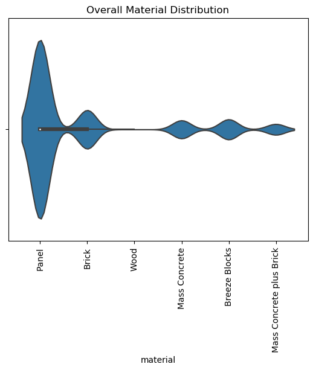

```python
# Define list of material names
material_names = ["", "Panel", "Brick", "Wood", "Mass Concrete", "Breeze Blocks", "Mass Concrete plus Brick"]

# Plot the distribution of materials with a violin plot to get a better idea of how materials compare
df.material.value_counts().values
v = sns.violinplot(x=df.material)
v.set_xticklabels(material_names, rotation='90')
v.set_title("Overall Material Distribution")
plt.show()
```

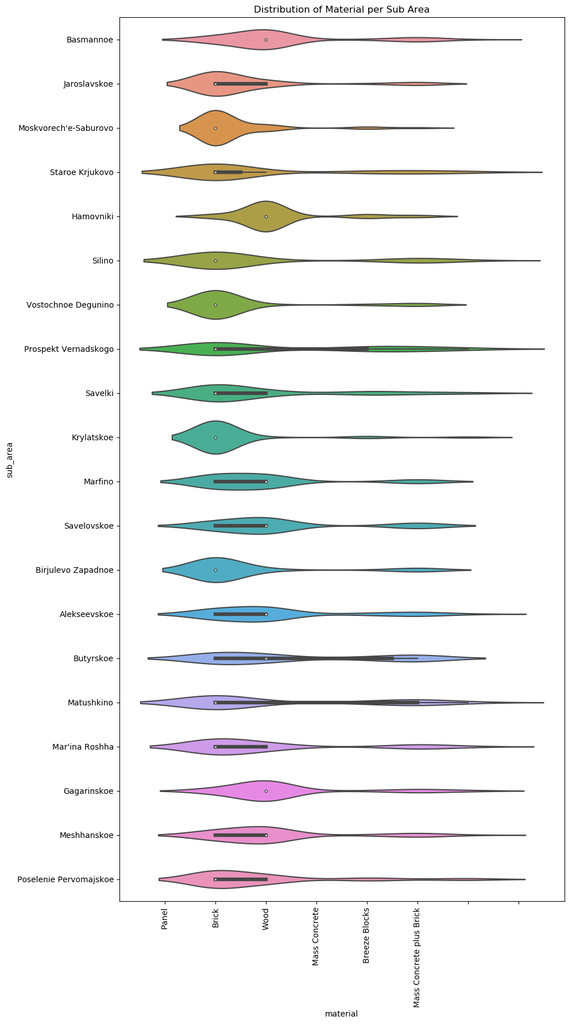

```python
# Plot distribution of materials for each individual sub area to see how they compare (could be correlated with average prices)
f, ax = plt.subplots(figsize=(10, 20))
sa = df.loc[df.sub_area.isin(df.sub_area.value_counts().keys()[-50:-30])]
v = sns.violinplot(x=sa.material, y=sa.sub_area, ax=ax)
v.set_xticklabels(material_names, rotation='90')
v.set_title("Distribution of Material per Sub Area")
plt.show()
```

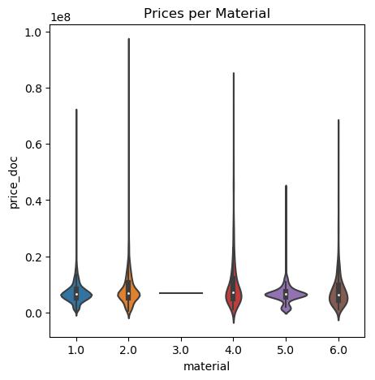

```python
# Group by state and calculate the price average
sorted_state = df.groupby("material")["price_doc"].mean().sort_values().reset_index()["material"]

# Rank states by their average price
sorterIndex = dict(zip(sorted_state,range(len(sorted_state))))

# Create new column for state rank
df['material_rank'] = df['material'].map(sorterIndex)

# Sort DataFrame by state rank
df1 = df.sort_values(by='material_rank')

# Plot state in order of their average price
f, ax = plt.subplots(figsize=(5, 5))
p = sns.violinplot(x=df1.material, y=df1.price_doc, ax=ax)
p.set_title("Prices per Material")
plt.show()
```

### 3.7. Prices of Different Property States

The following analysis examine the `state` attribute, which represents the condition of the property (1 meaning the property is in a poor condition, and 4 meaning the property is in an immaculate condition). Intuitively, we thought that the poorer the condition of the property, the less it's sale price. However, we see that this is not necessarily the case. The below violin plot shows that between condition classes 1-3, the sale price distributions are relatively the same. The peaks of each plot show a slight increase as condition improves, although there is no significant differences. In contrast, the 4th class, which means the property is in great condition, does seem to slightly increase the general property sale price (as the distribution is much more spread out). From this analysis, we conclude that the `state` attribute may not be as significant of an indicator for sale price as we previously expected.

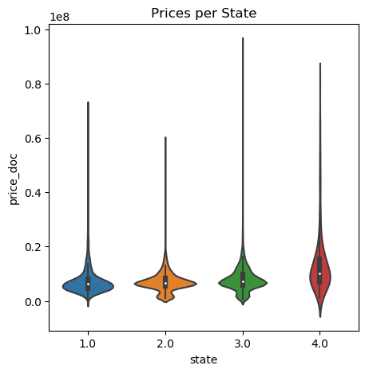

```python
# Group by state and calculate the price average
sorted_state = df.groupby("state")["price_doc"].mean().sort_values().reset_index()["state"]

# Rank states by their average price
sorterIndex = dict(zip(sorted_state,range(len(sorted_state))))

# Create new column for state rank
df['state_rank'] = df['state'].map(sorterIndex)

# Sort DataFrame by state rank
df1 = df.sort_values(by='state_rank')

# Plot state in order of their average price
f, ax = plt.subplots(figsize=(5, 5))
p = sns.violinplot(x=df1.state, y=df1.price_doc, ax=ax)
p.set_title("Prices per State")
plt.show()
```

### 3.8. Time Series Visualisation

Here we analyse the general time series characteristics of the data. Specifically, we look at the monthly average house sale price over time. Firstly, we are able to see that, after pre-processing, the dataset contains property sales from August 2011 to June 2015. In the first half of 2012 there was a rather large increase in property price, before it slowly dropped back down in the second half of the year. Since the beginning of 2013 however, property sale price has rather steadily increased. The fact that there is a trend present in the data may make forecasting methods quite accurate at predicting house price. Furthermore, investigating the performance of regression methods with and without time information may lead to interesting results we can examine in the final report.

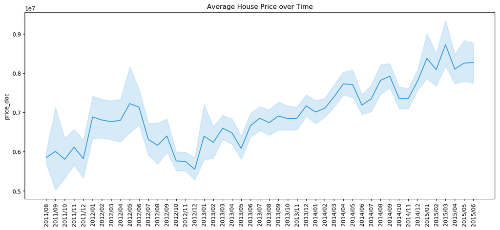

```python
years = df['timestamp'].str[:4]
months = df['timestamp'].str[5:7]
days = df['timestamp'].str[8:10]
df['year'] = years
df['month'] = months
df['day'] = days

yearMonth = df['year'] + '/' + df['month']
f, ax = plt.subplots(figsize=(15, 6))
sns.lineplot(yearMonth, df['price_doc'], color='#3498db')
plt.xticks(rotation=90)
plt.title('Average House Price over Time')
plt.show()
```

### 3.9. Influence of Size on House Price

From plotting both `full_sq` and `life_sq` against price we can see how they each influence price and the overall difference between them. From the plot, we can see a gradual positive gradient of `life_sq` and `full_sq` as the price increases, allowing us to explicitly the see the strong positive correlation between price that we saw in our correlation matrix. Apart from the majority of points, we saw a few outliers where `full_sq` and or `life_sq` were far greater yet price was still at the low end of the distribution. It seems likely that some of these points are noise, but we have no other mechanism for determining their validity. As per our data cleaning section, the exception is when `life_sq` is greater than `full_sq`.

By taking the difference of `life_sq` and `full_sq` we extract the impact of non-residential areas on price. From this we see a far lower degree of influence over house prices as points stay relatively low and flat as price increases.

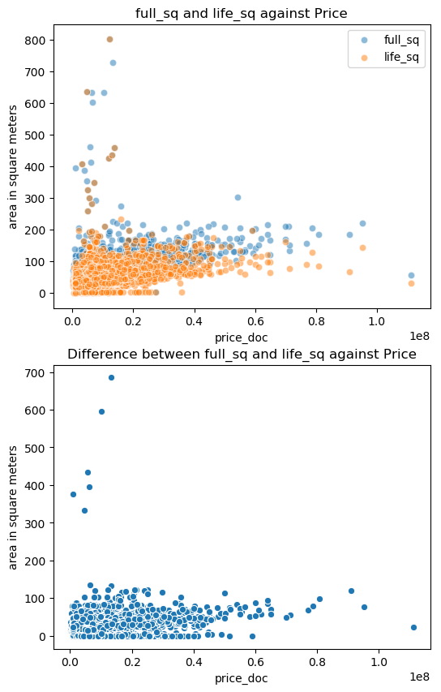

```python
# Plot the first graph of full_sq and life_sq against price
fig, ax = plt.subplots(2, 1, figsize=(6, 10))
sns.scatterplot(df.price_doc, df[df.full_sq < 5000]['full_sq'], ax=ax[0], alpha=0.5)
sns.scatterplot(df.price_doc, df[df.life_sq < 7000]['life_sq'], ax=ax[0], alpha=0.5)
ax[0].set_ylabel("area in square meters")
ax[0].set_title("full_sq and life_sq against Price")
ax[0].legend(["full_sq", "life_sq"])

# Plot the second graph of the difference between full_sq and life_sq against price
sns.scatterplot(df.price_doc ,(df[df.full_sq < 5000]['full_sq'] - df[df.life_sq < 7000]['life_sq']), ax=ax[1])
ax[1].set_title("Difference between full_sq and life_sq against Price")
ax[1].set_ylabel("area in square meters")

plt.show()
```

### 3.10. Insights into Housing Construction over Time

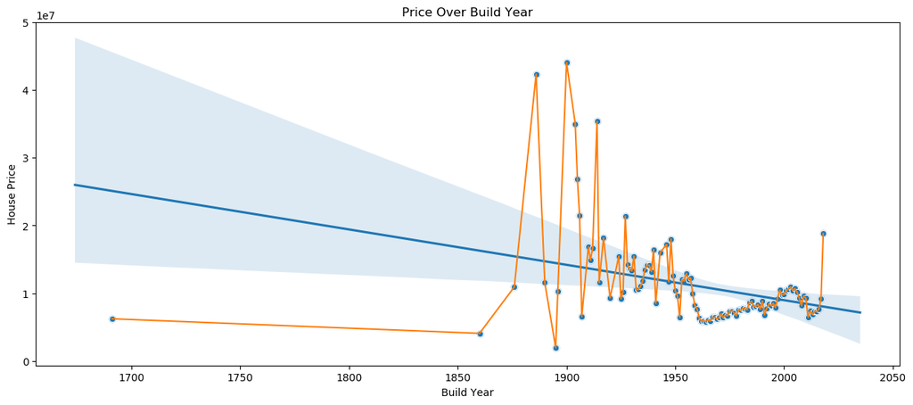

```python
## Plot Price over Building Age by grouping by build year and taking the average
f, ax = plt.subplots(figsize=(15, 6))
df1 = df.groupby("build_year")["price_doc"].mean().reset_index()
sns.regplot(df1.build_year, df1.price_doc, ax=ax)
sns.lineplot(df1.build_year, df1.price_doc, ax=ax)
sns.scatterplot(df1.build_year, df1.price_doc, ax=ax)

ax.set(title="Price Over Build Year", xlabel="Build Year")
ax.set_ylabel("House Price")
plt.show()
```